# 2025 Pre-assessment workshop for Rougheye and Blackspotted rockfishes in waters off the US West Coast

Jason M. Cope, Northwest Fisheries Science Center

Vladlena Gertseva, Northwest Fisheries Science Center

Fabio P. Caltabellotta, Washington Department of Fish and Wildlife

R. Claire Rosemond, Northwest Fisheries Science Center

Alison D. Whitman, Oregon Department of Fish and Wildlife

2025-02-19

*Disclaimer: All data summaries and exploration presented here are preliminary and may not be indicative of the final data that will be incorporated in the 2025 assessment models*

# Overview

Description of data and model specification being considered for use in the 2025 Rougheye and Blockspotted rockfishes assessment. Both of these species are treated as a rockfish complex, as they are difficult to visually separate, and thus most data are only available as combined Rougheye/Blackspotted rockfishes.

# Summary of the 2013 Assessment

The last assessment of the Rougheye and Blackspotted rockfishes in U.S. west coast waters was conducted in 2013 and estimated stock status for the beginning of that year at 47% of the unfished stock size, and never showed a decline below the target biomass of 40% of the unfished stock size (**Figures 1 and 2**). This assessment was informed by both length and age compositions, mean weights, and several indices of abundance. Despite the number of different data types, the large amount of ageing error and mostly flat and largely uncertain indices of abundance result in wide uncertainty intervals around the derived outputs like stock size and status . The complete assessment document can be found here.

# Bridging the assessment model from Stock Synthesis 3.24 to 3.30

More than 10 years have passed from the last assessment model and the Stock Synthesis 3 (SS3) modelling framework has undergone many changes. While the specific changes in the model can be found in the model [change log](https://github.com/orgs/nmfs-ost/projects/11), here we simply update the model from the older 3.24O version to the newer 3.30.22.1 version. We want to ensure that any update to the newest SS3 model is not a cause of any changes in model outputs when we hold all data and model specifications to be exactly the same as in 2013. We therefore transfered all the older data and model specifications to the newest version of SS3 and compared the outputs. The status (**Figure 1**) and scale (**Figure 2**) of both models are exactly the same, as are the estimates of within model uncertainty. This allows us to conclude that we can move forward using the latest version of SS3 without having to worry about inheriting any model difference due solely to the choice of SS3 version.

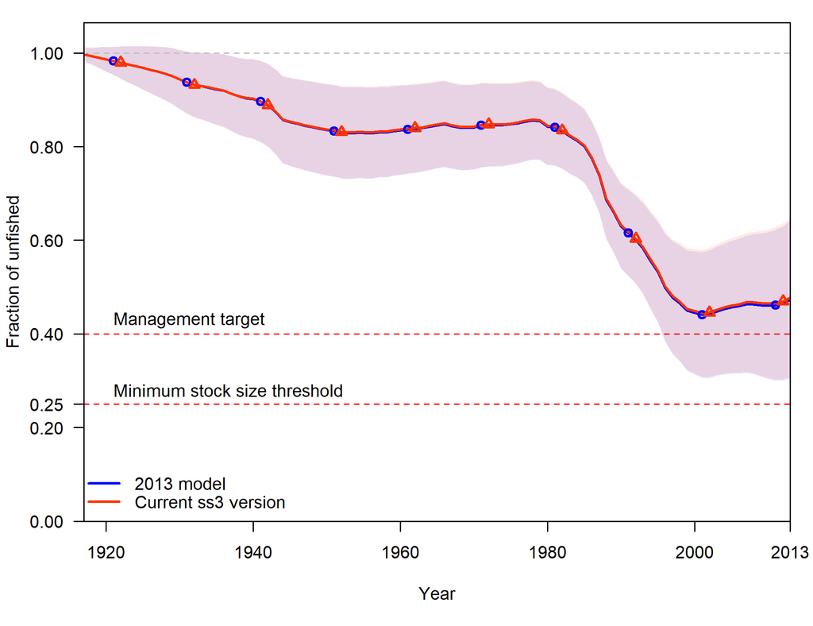

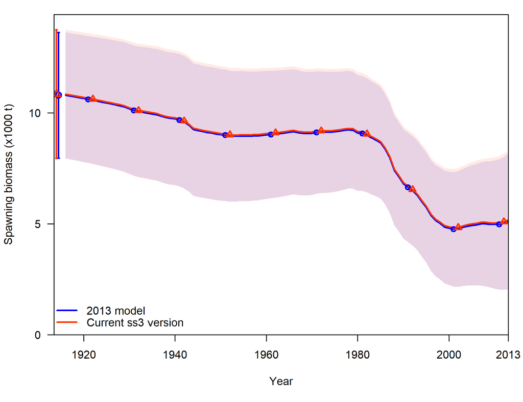

1. Historical landings and discards.
2. Natural mortality.
3. Maturity and fecundity.
4. Age data and error.
5. Understanding the stock structure and biology of rougheye and blackspotted rockfishes.

# Stock Structure

There are at least two questions to consider when considering stock structure for Rougheye and Blackspotted rockfishes.

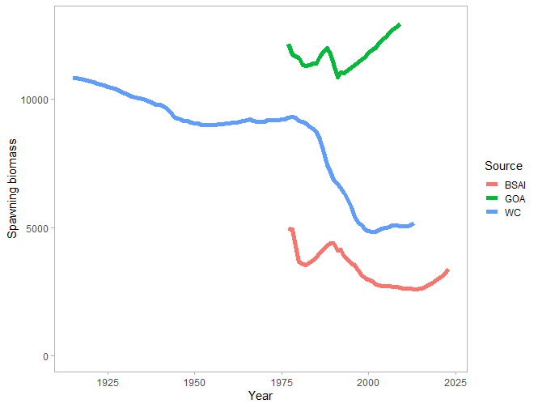

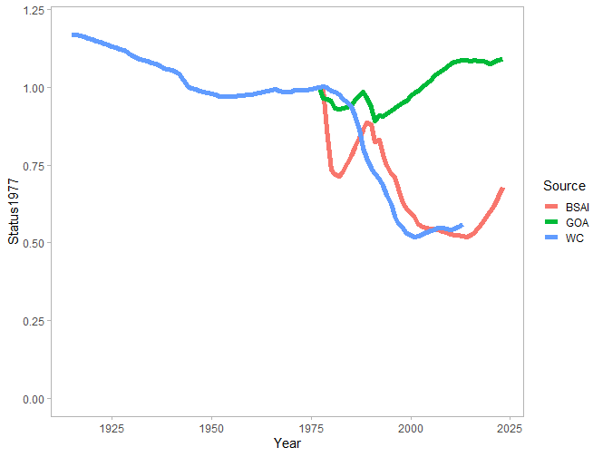

**Figure 4. Estimates of relative stock size (current spawning output/unfished spawning output) relative to 1977 (the common year in all stock assessments compared) for the rougheye/blackspotted rockfish complex from the two most recent Alaska (Bering Sea/Aluetian Islands (BSAI) and Gulf of Alaska (GOA)) and the 2013 West Coast stock assessment.**

# Fleet Structure

Currently, the following fleet structure is being considered for modeling commercial fishery removals as there is no record of a recreational fishery for this stock complex:

1. Commercial trawl
2. Commercial fixed gear (mainly the long-line fishery)
3. At-sea hake fishery
4. Dead discard trawl
5. Dead discard non-trawl

Defining fleets is largely based on differing fleet selectivity (i.e., how the fishery captures fish by length and/or age). In the stock assessment model, selectivity translates into how the removals are taken via length and/or age out of the population. The above three fishery types are distinguished by different fishing activities that result in different selectivities. The first fleets are the same as those defined in the 2013 assessment, but we plan on adding an additional two discard fleets instead of modelling retention (**Figure Discard_1** shows this choice does not affect model results.). We plan on using a length-based selectivity curve for all fleets for the current stock assessment model (same as done in the 2013 assessment), as there is no reason to believe significant age-based selectivity is occurring. We will consider both logistic and dome-shaped selectivity options.

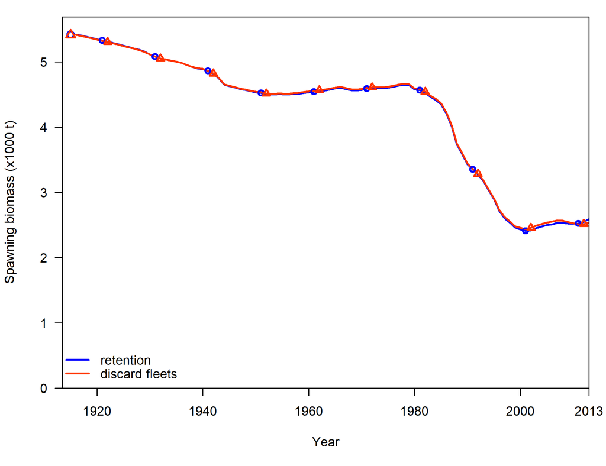

**Figure Discard_1. Comparison of spawning output using retention curves or discard fleets using the 2013 Rougheye/Blackspotted Rockfishes assessment.**

[figure not shown]

# Removal Data

## Commercial Landings & Discards

Rougheye/Blackspotted Rockfish

Commercial landings are the main source of removals for Rougheye/Blackspotted rockfishes. They are a mainly slope species, typically found around 365m (~200 fathoms), but can also be common shallower (down to 275m). This complex is known to school, this increasing encounters when in an area and available. Trawl and non-trawl (mostly long-line) are the two major fleets they are taken in, with the at-sea-hake midwater fishery also encountering them in notable numbers over the past two decades. Landings are lower in California (**Figure Ct_CA**) and increase northward, with the biggest trawl catches in Oregon (**Figure Ct_OR**), and biggest non-trawl catches in Washington state (**Figure Ct_WA**). There was also a notable catch of Rougheye/Blackspotted accounted for in the trawl fishery that came from the foreign fleet Pacific Ocean Perch fishery in the 1960s.

There are some updates in landings by state and fishery, but are overall small (**Figure Ct_All**). Landings over the couple of decades are generally lower than the previous two decades, though more discards are accounted for in the more recent years (**Figure Ct_fleets**). Updating the 2013 stock assessment with these newest catches leads to a small increase in overall spawning stock output (**FIgure Figure Ct_compsSO**), and essentially no change in the relative stock status (**FIgure Figure Ct_compsRSS**).

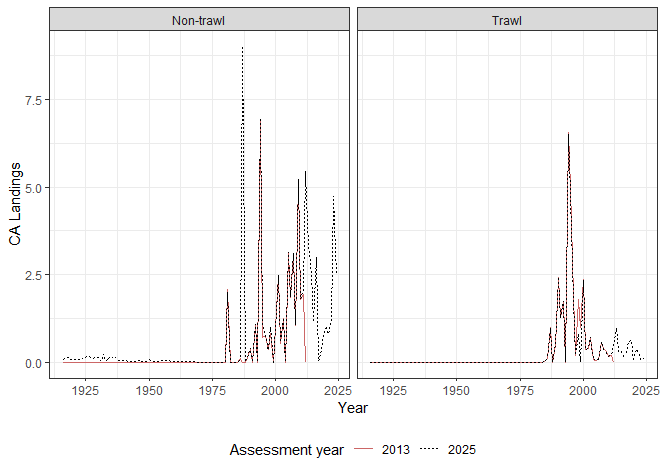

**Figure Ct_CA. California state landings for non-trawl and trawl fisheries compared between the 2013 assessment and updated landings for the 2025 stock assessment model.**

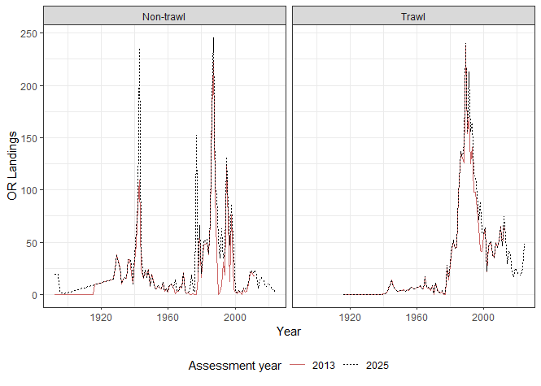

**Figure Ct_OR. Oregon state landings for non-trawl and trawl fisheries compared between the 2013 assessment and updated landings for the 2025 stock assessment model.**

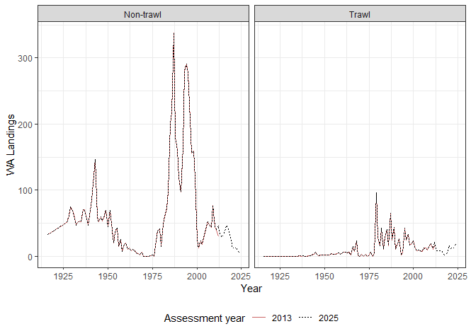

**Figure Ct_WA. Washington state landings for non-trawl and trawl fisheries compared between the 2013 assessment and updated landings for the 2025 stock assessment model.**

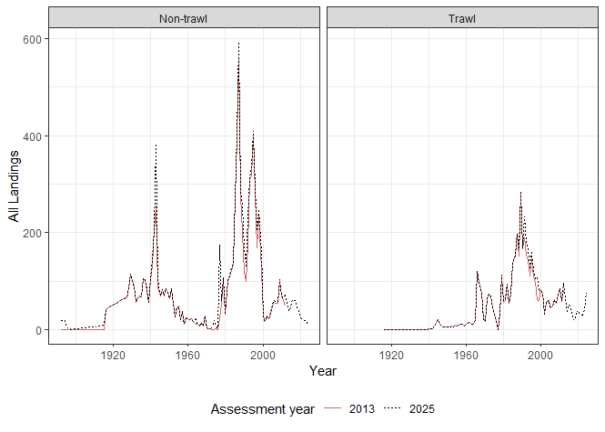

**Figure Ct_All. Landings across alls states for non-trawl and trawl fisheries compared between the 2013 assessment and updated landings for the 2025 stock assessment model.**

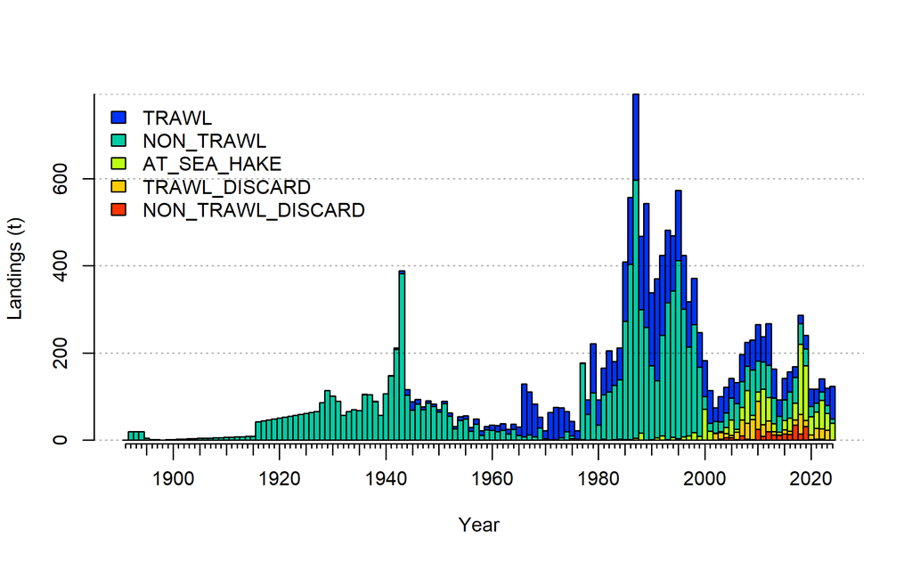

**Figure Ct_fleets. Landings across alls fleets used in the 2025 stock assessment.**

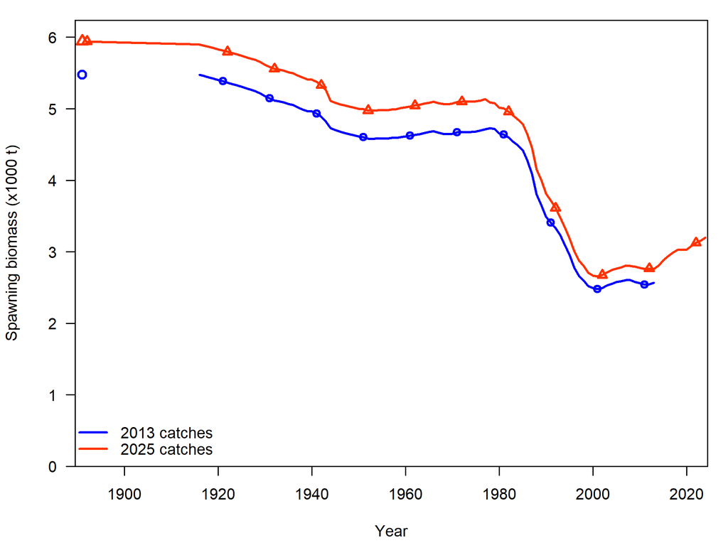

**Figure Ct_compsSO. Comparison of spawning output using updated catches vs using catches from the 2013 Rougheye/Blackspotted Rockfishes assessment.**

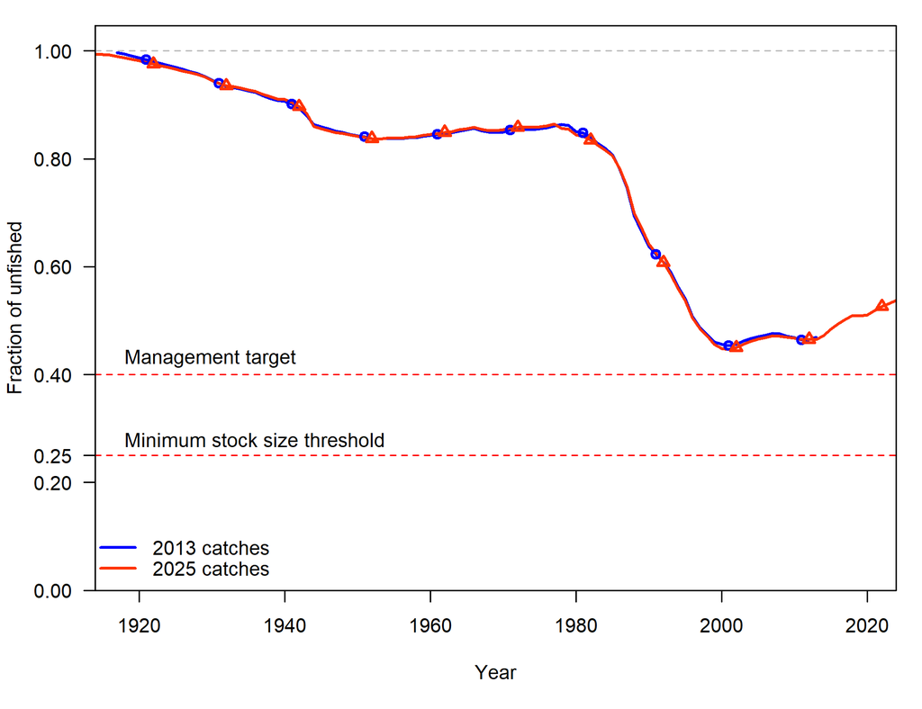

**Figure Ct_compsRSS. Comparison of relative spawning output using updated catches vs using catches from the 2013 Rougheye/Blackspotted Rockfishes assessment.**

### Additional Items for Discussion

# Indices of Abundance

Only the WCGBTS has new data for this assessment, but new methods (Spatial and spatiotemporal GLMMs with TMB or [sdmTMB](https://pbs-assess.github.io/sdmTMB/)) to develop an index of abundance were applied to all surveys to update all indices. Two distributions (gamma and lognormal) were considered, as was the case in 2013 model when a non-spatial generalized linear mixed model was used to develop indices of abundance.

Comparing the standardized versions (i.e., Z-scores) of the indices shows very similar trends among each model output (**Figure Z_score_Indices**), suggesting little difference in choice of model type. The variance in the indices are generally high (0.3-0.5; **Figure Sd_log_Indices**), suggesting the information content in these indices is low. This is not a surprise given the challenge of sampling these species with trawl data.

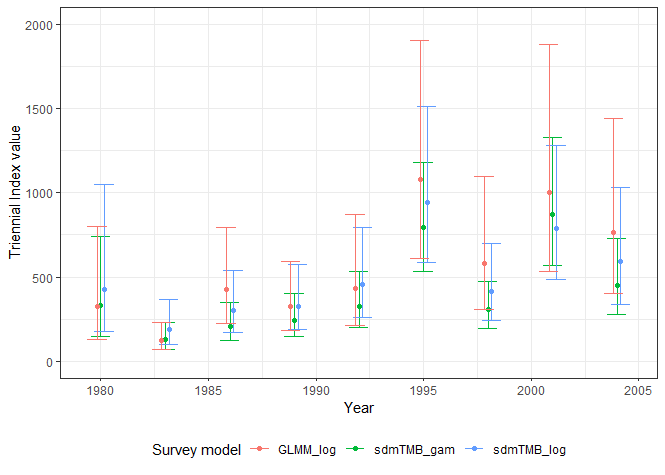

**Figure Index_Tri. Comparison of index values for the Triennial Trawl Survey using the 2013 GLMM approach and the 2025 sdmTMB approaches. Error bars are 95% confidence intervals.**

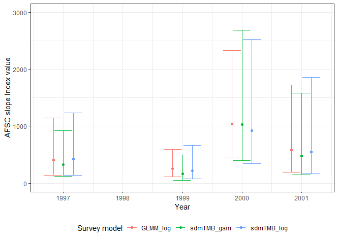

**Figure Index_AFSC_slope. Comparison of index values for the Alaska Fishery Science Center Slope Survey using the 2013 GLMM approach and the 2025 sdmTMB approaches. Error bars are 95% confidence intervals.**

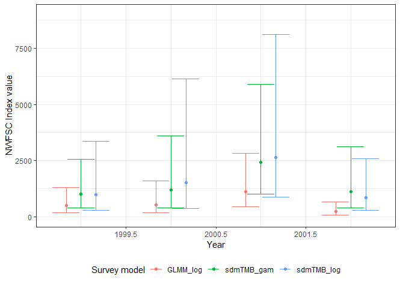

**Figure Index_NWFSC_slope. Comparison of index values for the NWFSC Slope Survey using the 2013 GLMM approach and the 2025 sdmTMB approaches. Error bars are 95% confidence intervals.**

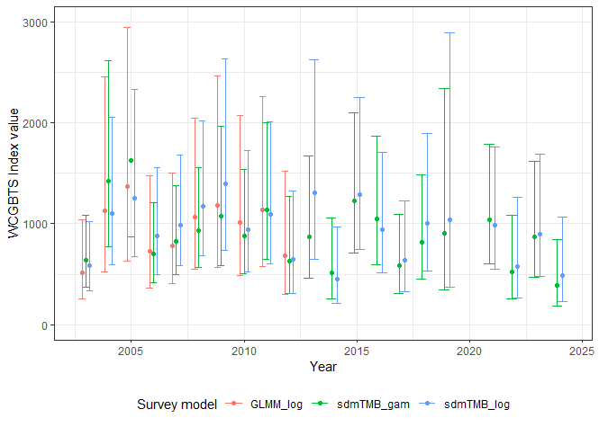

**Figure Index_WCGBTS. Comparison of index values for the West Coast Groundfish Bottom Trawl Survey using the 2013 GLMM approach and the 2025 sdmTMB approaches. Error bars are 95% confidence intervals.**

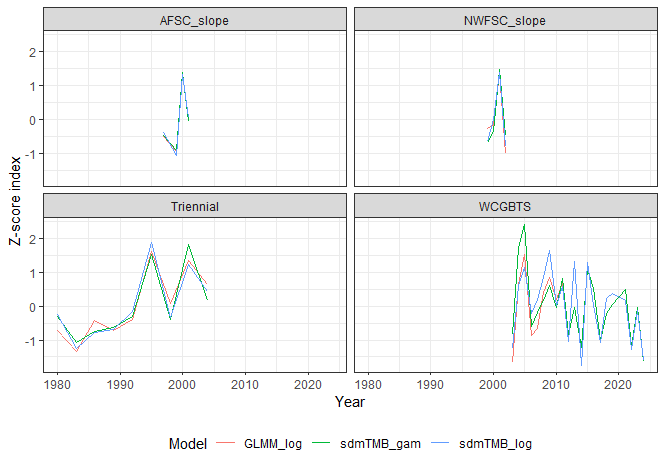

**Figure Index_Zscore. Comparison of model-based index Z-score values by each survey. Z-scores standardize the scale of the index so different model outputs can be compared.**

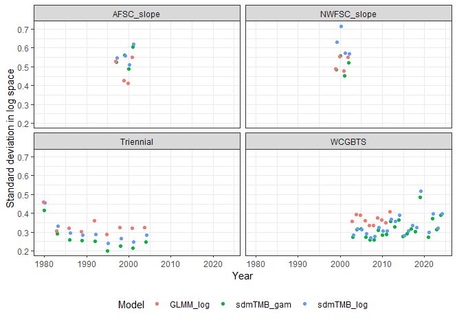

**Figure Index_sdlog. Comparison of model-based log-space standard deviation values by each survey. These measures of uncertainty are comparable across models and among surveys.**

Details on the WCBGTS index: the data were truncated to depths less than 875 m prior to modelling given that there were zero positive encounters in depths deeper than 875 m. The prediction grid was also truncated to only include available survey locations in depths between 55-875 m to limit extrapolating beyond the data and edge effects.

The response variable in the model was catch (mt) with an offset of area (km2) to account for differences in effort. Fixed effects were estimated for each year. The following additional covariate was included: pass.

Spatial variation, but not spatiotemporal variation, was included in the encounter probability and the positive catch rate model. Spatial variation was approximated using 200 knots, where more knots led to non-estimable standard errors because the positive encounters are too sparse to support the dense spatiotemporal structure.

## Additional Items for Discussion

- Are there any other indices we should be considering?

# Composition Data

## Commercial length compositions

The 2013 assessment considered blocking of selectivity as well as dome-shaped selectivity for all fleets and surveys. Given the difficult to access and sample habitats of Rougheye and Blackspotted rockfishes with the two major gears, natural refugia (based on depth and rugged habitat preference) may explain why older, larger individuals are less accessible, thus a dome-shaped selectivity. That said, large and old individuals are encountered in both fisheries and surveys, some there is some selection occurring for the sizes and ages.

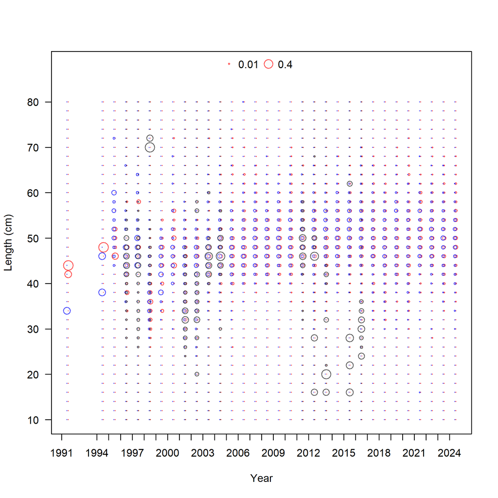

**Figure Lt_trawl. Length composition data by sex and year for the Rougheye/Blackspotted rockfish complex based on fish sampled in the trawl fishery.**

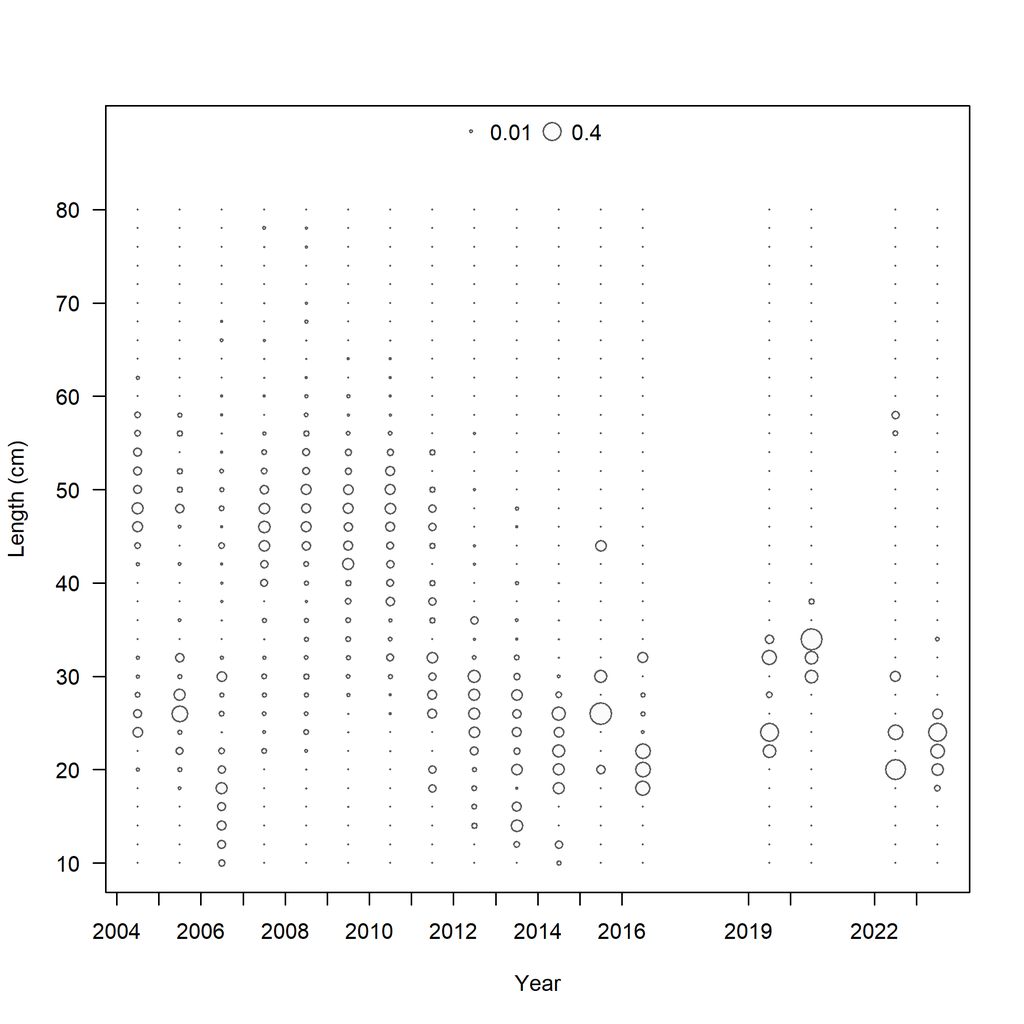

**Figure Lt_trawl_discard. Length composition data by sex and year for the Rougheye/Blackspotted rockfish complex based on dead discarded fish in the trawl fishery.**

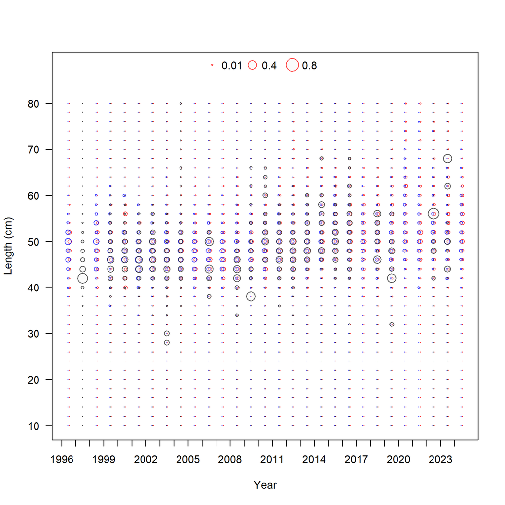

**Figure Lt_nontrawl. Length composition data by sex and year for the Rougheye/Blackspotted rockfish complex based on fish sampled in the non-trawl fishery.**

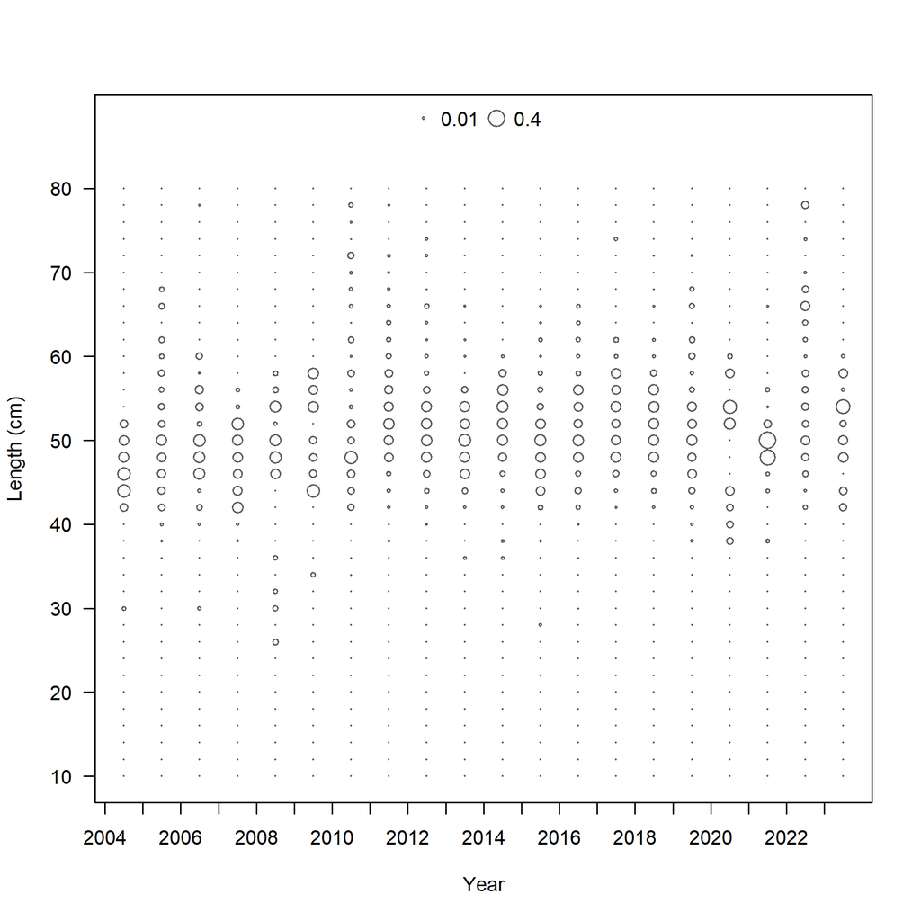

**Figure Lt_nontrawl_discard. Length composition data by sex and year for the Rougheye/Blackspotted rockfish complex based on dead discarded fish in the non-trawl fishery.**

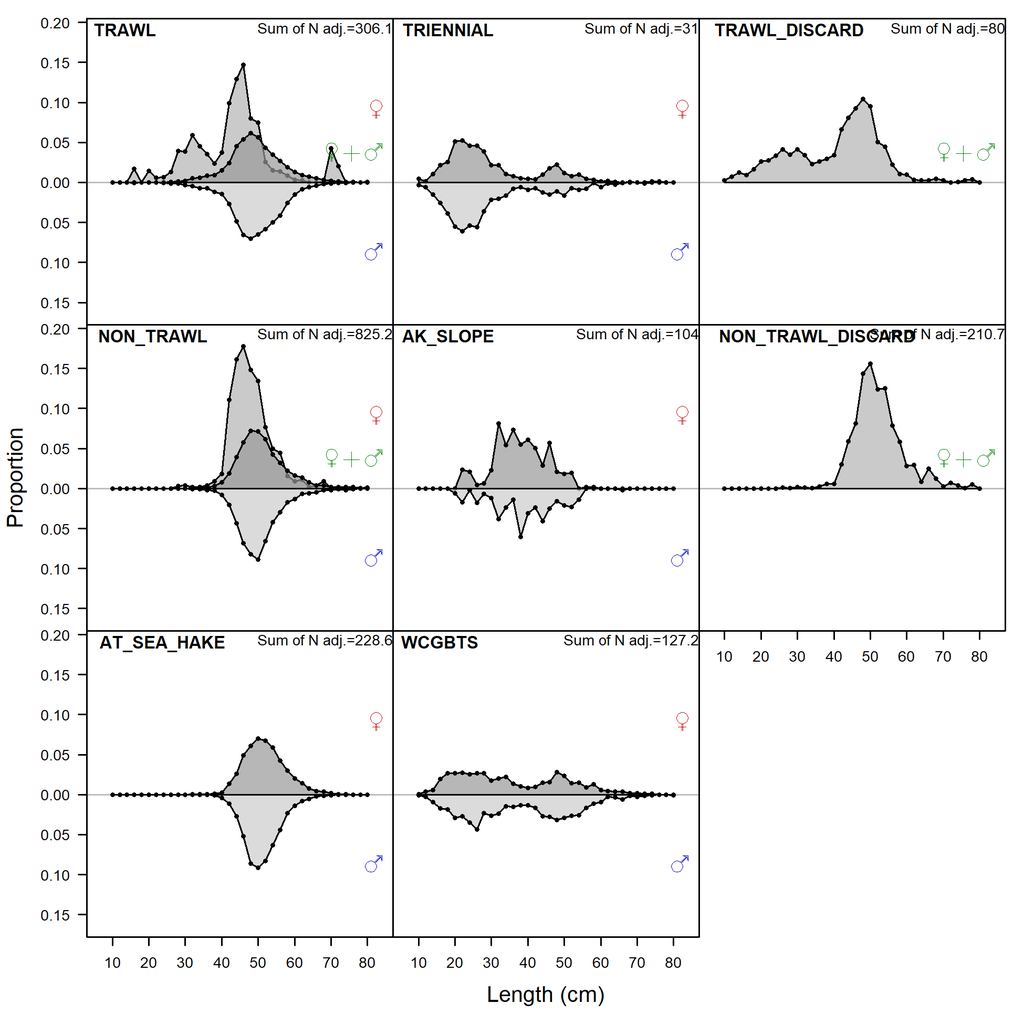

**Figure Lt_agg. Aggregated length composition data over all years by year, sex and fleet for the Rougheye/Blackspotted rockfish complex.**